# 624_HW1

Sean Connin

02/02/22

```r
library(fpp3)
library(magrittr)
library(tidyverse)
library(patchwork)
library(readxl)
library(flextable)
library(USgas)
```

# 1 Time Series Graphics: Q1

**Use the help function to explore what the series gafa_stock, PBS, vic_elec and pelt represent.**

- gafa_stock: Historical stock prices from 2014-2018 for Google, Amazon, Facebook and Apple. All prices are in $USD.
- PBS: Monthly Medicare Australia prescription data
- elec_vic: half-hourly electricity demand for Victoria, Australia
- pelt: Hudson Bay Company trading records for Snowshoe Hare and Canadian Lynx furs from 1845 to 1935.

**Use autoplot() to plot some of the series in these data sets.**

**What is the time interval of each series?**

- gafa_stock: *day*
- pbs: *month*
- vic_elec: *1/2 hour*
- pelt: *annual*

[figure not shown]

```r
# explore series

help(gafa_stock)

help(PBS)

help(vic_elec)

help(pelt)

# 1.a. Use autoplot() to plot some of the series in these data sets

#plot interannual closing price

amazon<-gafa_stock%>%    #closing daily stock price:Amazon
  filter(Symbol=='AMZN')

p1<-autoplot(amazon, Adj_Close, color='darkblue') +
  labs(title = "Amazon Adjusted Stock Closing Price",
       subtitle = "2014-2018",
       y = "Adjusted Closing Price ($)")+
  theme_classic()

# plot avg daily demand

daily_avg <- aggregate(Demand~Date,vic_elec, mean)%>% # avg daily demand: vic_elec
  as_tsibble()

p2<-autoplot(daily_avg, Demand, color='darkblue')+
  labs(title = "Average Daily Electricity Demand in Victoria, Australia",
       subtitle = " Year = 2012",
       y = "Demand (MW))")+
  theme_classic()

(p1/p2)
```

# 2 Time Series Graphics: Q2

**Use filter() to find what days corresponded to the peak closing price for each of the four stocks in gafa_stock.**

*AMZN: $2,039.51*

*GOOG: $1,268.33*

*AAPL: $232.07*

*FB: $217.50*

```r
# create function and map with purrr to find peak closing dates
# note we need to convert stibble to tibble

company<-set_names(c(gafa_stock$Symbol%>%unique()))

f = function(x) {
  gafa_stock%>%
  as_tibble()%>%
  filter(Symbol== x)%>%
  summarise(maxi=max(Close))%>%
  reduce(full_join, by = 'Symbol')
}

(max_close<-map_df(company, ~f(.x))%>%pivot_longer(cols = 1:4,names_to = "Company", values_to = "Peak_Close")%>%arrange(desc(Peak_Close))%>%flextable())
```

| Company | Peak_Close |
| --- | --- |
| AMZN | 2,039.51 |
| GOOG | 1,268.33 |
| AAPL | 232.07 |
| FB | 217.50 |

```r
# The following is a more streamlined means of finding peak closing prices

#gafa_stock%>%
  #as.tibble()%>%
  #select(Symbol, Close)%>%
  #group_by(Symbol)%>%
  #summarise(maxi=max(Close))%>%
  #arrange(desc(maxi))%>%
  #flextable()
```

# 3 Time Series Graphics: Q3

**Download the file tute1.csv from the book website, open it in Excel (or some other spreadsheet application), and review its contents.**

- Read the data into R
- Convert the data to time series
- Construct time series plots of each of the three series
- Check what happens when you don’t include facet_grid().

*Without facet_grid the three series are plotted on the same graph with a continuous scale for the y-axis. This compresses the plotted data (i.e., reduced amplitude) and, in turn, reduces an investigators ability to distinguish fine-grained patterns within and across series.*

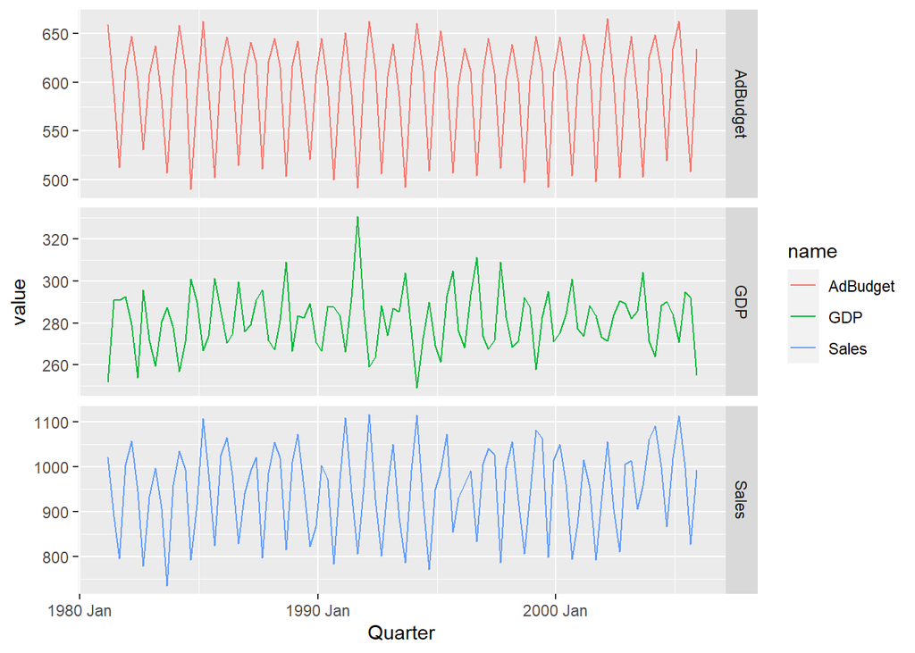

```r
# read data tute1 into R

tute1 <- read_csv("tute1.csv")

# convert tute1 into a time series

series <- tute1 %>%
  mutate(Quarter = yearmonth(Quarter)) %>% #tsibble represent year-month
  as_tsibble(index = Quarter) # date-times should be declared as index

# Construct time series plots of each of the three series

series %>%
  pivot_longer(-Quarter) %>%
  ggplot(aes(x = Quarter, y = value, colour = name)) +
  geom_line() +
  facet_grid(name ~ ., scales = "free_y")
```

# 4 Time Series Graphics: Q4

**The USgas package contains data on the demand for natural gas in the US.**

- Install the USgas package.
- Create a tsibble from us_total with year as the index and state as the key.
- Plot the annual natural gas consumption by state for the New England area (comprising the states of Maine, Vermont, New Hampshire, Massachusetts, Connecticut and Rhode Island).

*Note: USgas consists of three data sets:us_monthly, us_total, us_residential.*

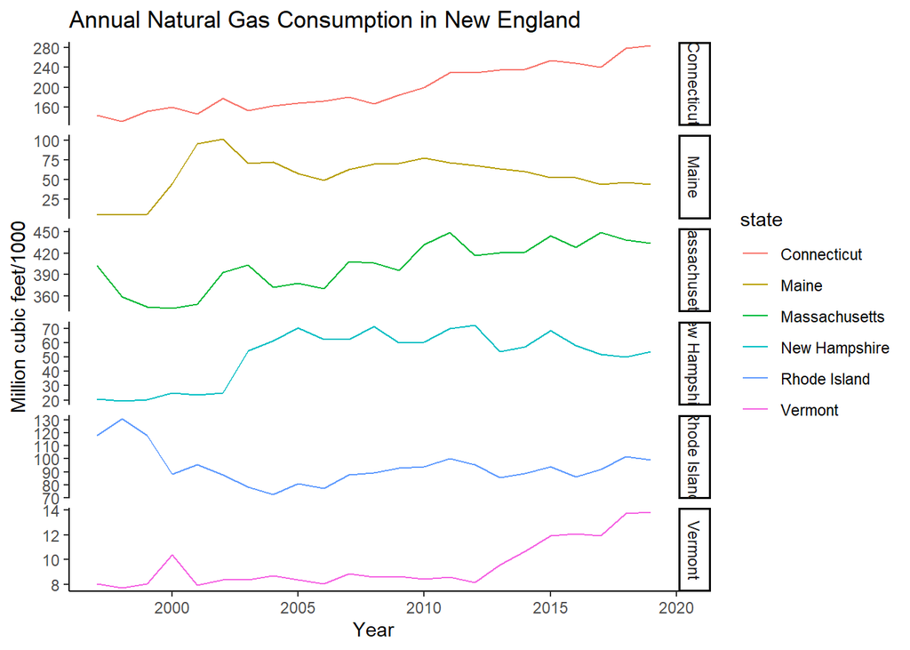

```r
# create tsibble from us_total with year as the index and state as the key

total <- USgas::us_total%>%
  as_tsibble(key=state, index = year)

#Plot the annual natural gas consumption by state for the New England area (comprising the states of Maine, Vermont, New Hampshire, Massachusetts, Connecticut and Rhode Island).

total%>%
  filter(state %in% c('Maine', 'Vermont', 'New Hampshire', 'Massachusetts', 'Connecticut', 'Rhode Island'))%>%
  mutate_at(vars(y),funs(y=y/1000))%>% # data = units of million cubic feet: divide by 1000 for rendering
  autoplot()+
  labs(title= 'Annual Natural Gas Consumption in New England', y = 'Million cubic feet/1000', x= 'Year')+
  theme_classic()+
  facet_grid(state ~ ., scales = "free_y")
```

# 5 Time Series Graphics: Q5

**Download tourism.xlsx from the book website and read it into R using readxl::read_excel().**

- Create a tsibble which is identical to the tourism tsibble from the tsibble package.
- Find what combination of Region and Purpose had the maximum number of overnight trips on average.
- Create a new tsibble which combines the Purposes and Regions, and just has total trips by State.

*Other combinations are included in Table 5.1 below.*

```r
# make tsibble identical to tsibble::tourism
# we need to change Quarter col to Date when importing Excel

tourism<-read_excel('tourism.xlsx')
tourism$Quarter<-as.Date(tourism$Quarter)

tourism%>%
  as_tsibble(key=c(Region, State,  Purpose), index = Quarter)%>%
  mutate(Quarter = yearquarter(Quarter))
```

| Quarter | Region | State | Purpose | Trips |
| --- | --- | --- | --- | --- |
| 1998 Q1 | Adelaide | South Australia | Business | 135.0776903 |
| 1998 Q2 | Adelaide | South Australia | Business | 109.9873160 |
| 1998 Q3 | Adelaide | South Australia | Business | 166.0346866 |
| 1998 Q4 | Adelaide | South Australia | Business | 127.1604643 |
| 1999 Q1 | Adelaide | South Australia | Business | 137.4485333 |
| 1999 Q2 | Adelaide | South Australia | Business | 199.9125861 |
| 1999 Q3 | Adelaide | South Australia | Business | 169.3550898 |
| 1999 Q4 | Adelaide | South Australia | Business | 134.3579372 |
| 2000 Q1 | Adelaide | South Australia | Business | 154.0343980 |
| 2000 Q2 | Adelaide | South Australia | Business | 168.7763637 |

[output cut: 9990 more lines]

```r
# Combination of Region and Purpose with maximum number of overnight trips on average

aggregate(Trips ~ Region+Purpose, tourism, max)%>%
  group_by(Region)%>%
  arrange(desc(Trips))%>%
  slice(1)%>%
  arrange(desc(Trips))%>%
  flextable()%>%
  set_caption("Table 5.1: Maximum average number of overnight trips")
```

| Region | Purpose | Trips |
| --- | --- | --- |
| Melbourne | Visiting | 985.27840 |
| Sydney | Business | 948.12936 |
| South Coast | Holiday | 914.77283 |
| North Coast NSW | Holiday | 905.84500 |
| Brisbane | Visiting | 796.30206 |
| Gold Coast | Holiday | 711.03724 |
| Sunshine Coast | Holiday | 617.47597 |
| Australia's South West | Holiday | 612.08986 |
| Great Ocean Road | Holiday | 548.41108 |
| Experience Perth | Visiting | 538.26505 |
| Peninsula | Holiday | 477.86811 |
| Hunter | Holiday | 451.22469 |
| Tropical North Queensland | Holiday | 383.39884 |
| Snowy Mountains | Holiday | 378.14346 |
| High Country | Holiday | 357.75049 |
| Phillip Island | Holiday | 315.97665 |
| Canberra | Holiday | 299.83128 |
| Australia's North West | Business | 296.80234 |
| Central NSW | Holiday | 284.65414 |
| Central Coast | Holiday | 280.61938 |
| Hobart and the South | Holiday | 275.04495 |
| Adelaide | Visiting | 269.53562 |
| Gippsland | Holiday | 261.86311 |
| Geelong and the Bellarine | Holiday | 243.27757 |
| Darling Downs | Visiting | 242.53206 |
| Central Queensland | Holiday | 214.34825 |
| Blue Mountains | Holiday | 206.22652 |
| Fleurieu Peninsula | Holiday | 205.15906 |
| Lakes | Holiday | 201.34897 |
| Australia's Coral Coast | Holiday | 198.17779 |
| The Murray | Holiday | 196.55227 |
| Bendigo Loddon | Visiting | 190.36415 |
| Central Murray | Holiday | 186.54155 |
| New England North West | Visiting | 178.95063 |
| Australia's Golden Outback | Business | 173.85992 |
| Launceston, Tamar and the North | Holiday | 157.96940 |
| East Coast | Holiday | 157.58189 |
| Flinders Ranges and Outback | Holiday | 156.14313 |
| Capital Country | Visiting | 155.99330 |
| Northern | Visiting | 150.21740 |
| Whitsundays | Holiday | 143.63325 |
| Yorke Peninsula | Holiday | 138.03573 |
| Riverina | Visiting | 135.58845 |
| Darwin | Holiday | 132.99124 |
| Mackay | Business | 132.53898 |
| Fraser Coast | Holiday | 130.82576 |
| Outback | Business | 130.22385 |
| Melbourne East | Visiting | 125.18315 |
| North West | Holiday | 118.89323 |
| Mallee | Holiday | 115.03198 |
| Limestone Coast | Holiday | 112.93466 |
| Upper Yarra | Holiday | 106.31121 |
| Goulburn | Visiting | 105.36416 |
| Ballarat | Visiting | 102.81502 |
| Central Highlands | Holiday | 99.62681 |
| Outback NSW | Holiday | 97.37752 |
| Bundaberg | Visiting | 95.28684 |
| Eyre Peninsula | Holiday | 94.90047 |
| Spa Country | Holiday | 85.73199 |
| Katherine Daly | Holiday | 84.97401 |
| Lasseter | Holiday | 84.94788 |
| Wilderness West | Holiday | 84.88036 |
| Kakadu Arnhem | Holiday | 82.49212 |
| Murraylands | Holiday | 81.13738 |
| Adelaide Hills | Visiting | 81.10211 |
| Riverland | Holiday | 78.26580 |
| Alice Springs | Holiday | 76.54138 |
| Western Grampians | Holiday | 65.64098 |
| Macedon | Visiting | 59.78706 |
| Barossa | Holiday | 51.00731 |
| Wimmera | Visiting | 42.51681 |
| Clare Valley | Holiday | 42.23342 |
| Murray East | Business | 40.18606 |
| Barkly | Holiday | 37.87040 |
| Kangaroo Island | Holiday | 36.89924 |
| MacDonnell | Holiday | 28.50539 |

[figure not shown]

```r
# total trips by state

trips_state<-aggregate(Trips~Quarter+State, tourism, sum)%>%
    arrange(State)%>%
    as_tsibble(key=State, index = Quarter)

#plot total trips for visual assessment

trips_state%>%
  autoplot(.vars=Trips)+
  labs(title= 'Total Trips by State: 2000-2015', y = 'Number of Trips', x= 'Year')+
  theme_classic()+
  facet_grid(State ~ ., scales = "free_y")
```

# 6 Time Series Graphics: Q8

**Monthly Australian retail data is provided in aus_retail. Select one of the time series as follows (but choose your own seed value):**

set.seed(12345678) myseries <- aus_retail %>% filter(`Series ID` == sample(aus_retail$`Series ID`,1))

**Explore your chosen retail time series using the following functions:**

- autoplot()
- gg_season()
- gg_subseries()
- gg_lag()
- ACF()

**Can you spot any seasonality, cyclicity and trend? What do you learn about the series?**

*See response below following the graphs.*

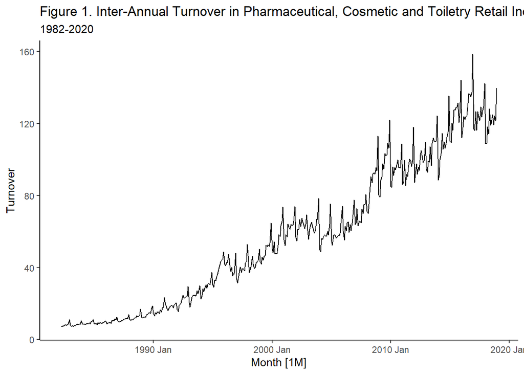

```r
set.seed(124566791)

# load data

series <- tsibbledata::aus_retail %>%
  filter(`Series ID` == sample(aus_retail$`Series ID`,1)) #1 specifies number of Series ID groups

# autoplot

p1<-series%>%
  autoplot(Turnover)+
  labs(title = 'Figure 1. Inter-Annual Turnover in Pharmaceutical, Cosmetic and Toiletry Retail Industry',
       subtitle = '1982-2020')+
  theme(axis.text.x = element_text(angle = 90))+
  theme_classic()

p2<-series%>%
  separate(Month, into=c('Year', 'Month'), sep=' ')%>%
  mutate(Year = as.numeric(Year))%>%
  filter(Year >= 1982)%>%
  ggplot(aes(Month, Turnover))+
  geom_point(aes( color=Year))+
  theme(axis.text.x = element_text(angle = 90))+
  labs(title = 'Figure 2. Monthly Turnover in Pharmaceutical, Cosmetic and Toiletry Retail Industry',
       subtitle = '1982-2020')+
  theme_classic()

# gg_season

p3<-series%>%
  gg_season(Turnover)+
  labs(title = 'Figure 3. Turnover in Pharmaceutical, Cosmetic and Toiletry Retail Industry',
       subtitle='By Month and Year')+
  theme_classic()

# gg_subseries

p4<-series%>%
  gg_subseries(Turnover)+
  labs(title = 'Figure 4. Turnover in Pharmaceutical, Cosmetic and Toiletry Retail Industry',
       subtitle='Subplots: Month and Year', x='Year')+
  theme_classic()+
  theme(axis.text.x = element_text(angle = 90))

# ACF

p5<-series%>%
  ACF(Turnover, lag_max=48) %>%
  autoplot()+
  labs('Figure 5. Autocorrelation: Turnover in Pharmaceutical, Cosmetic and Toiletry Retail Industry')+
  theme_classic()

# gg_lag

p6<-series%>%
  gg_lag(Turnover, geom = 'point', lags = 1:12)+
  labs(title = 'Figure 6. Lag in Turnover in Pharmaceutical, Cosmetic and Toiletry Retail Industry',
       x = "lag(Turnover, k)")+
  theme_classic()

# print plots

p1
```

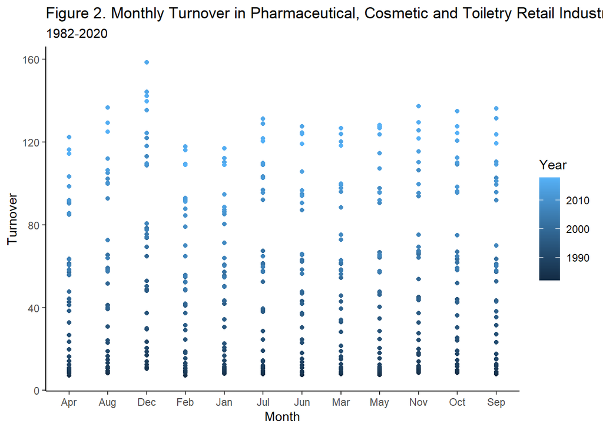

```r
p2
```

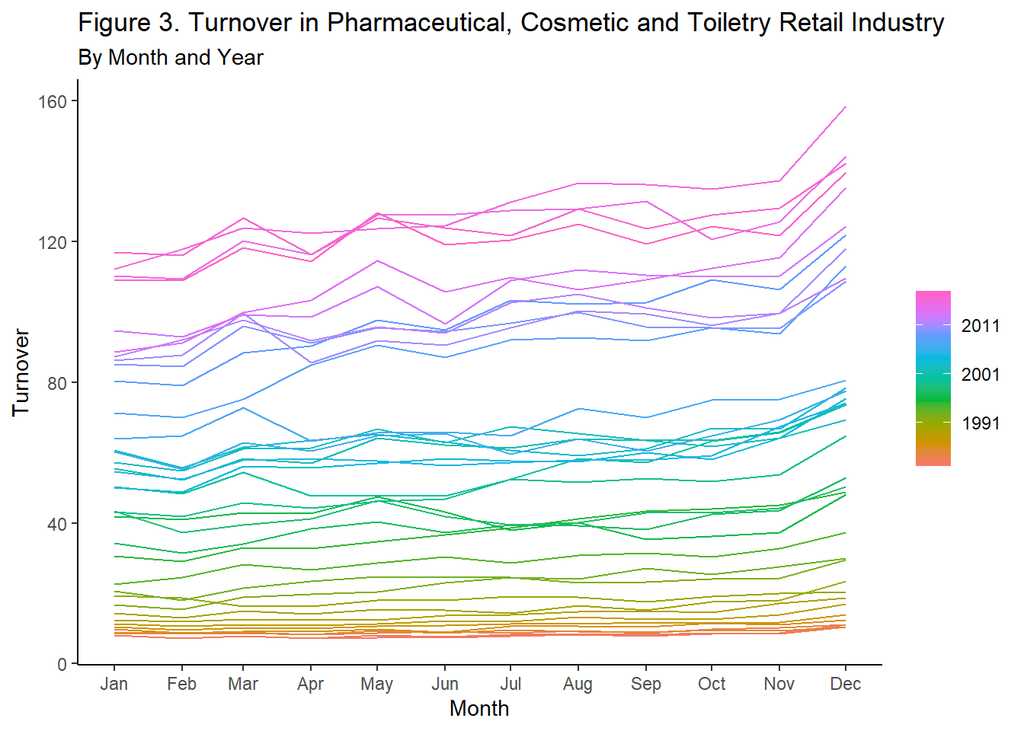

```r
p3
```

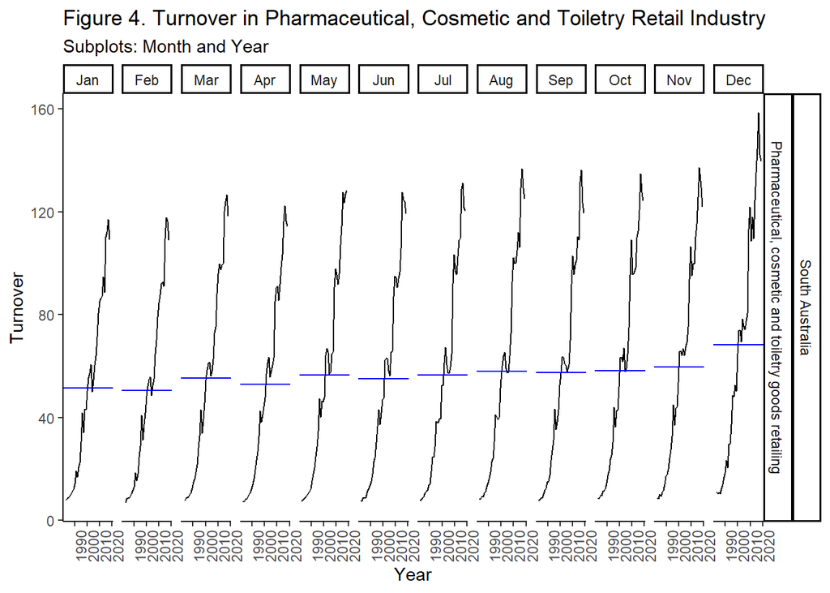

```r
p4
```

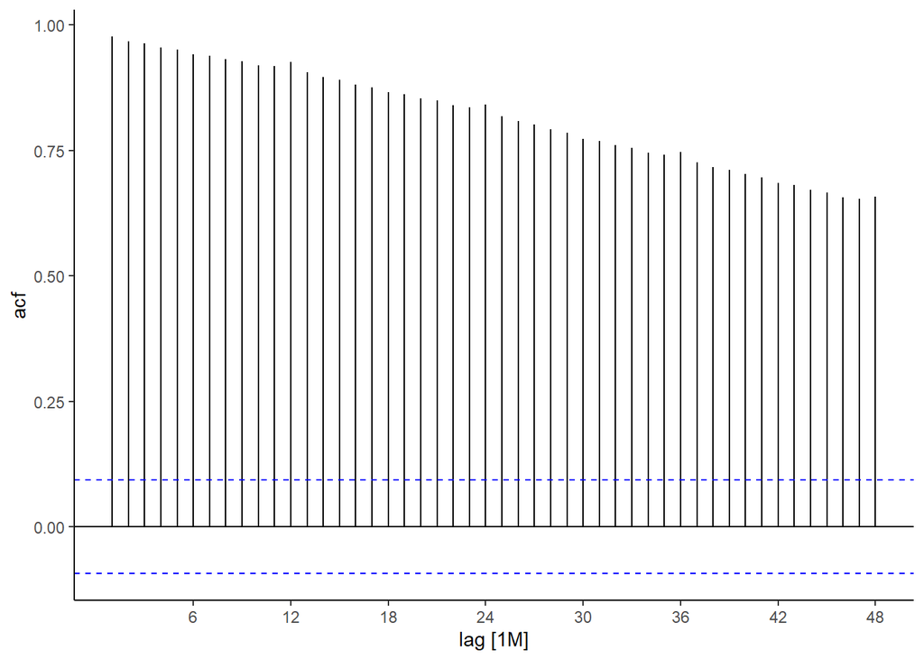

```r
p5
```

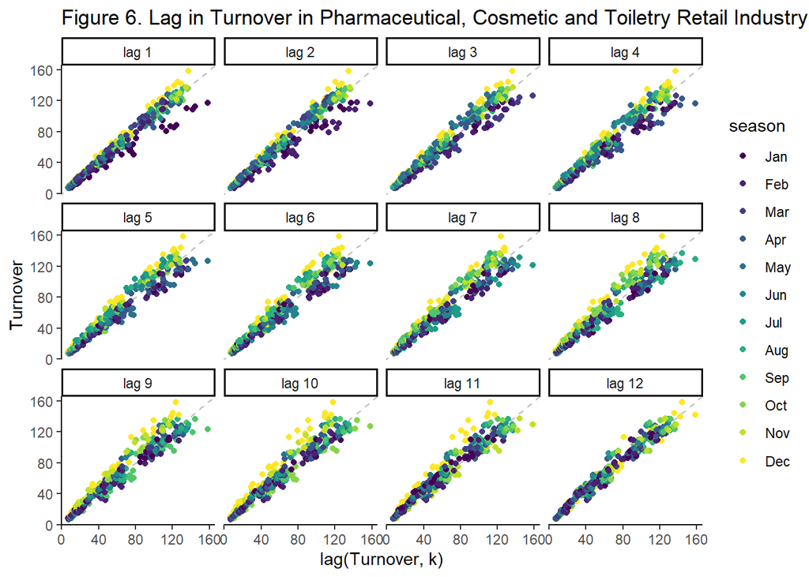

```r
p6
```

**Q8 Summary:**

The following patterns are apparent in this series:

*Retail turnover ($Million AUD) in the Pharmaceutical, Cosmetic, and Toiletry industry has increased since the early 1980’s, with greater seasonal and inter-annual variation subsequent to ~2008. There is a strong seasonal component with turnover spiking with the end-of-year holiday season, followed by a lull for several months. The possibility of a decadal cycle in the industry (if confirmed) is interesting and warrants further investigation.*